# Homework 2 Bayesian

Guillermo Filgueira

2026-04-23

## Problem 1

First we load the data and create the dummy variables.

```r
eagles <- read.csv("exercise/eagles.csv")

# creating dummy variables. 1 means large for P and V, and adult for A.
eagles$P_dum <- ifelse(eagles$P == "L", 1, 0)
eagles$V_dum <- ifelse(eagles$V == "L", 1, 0)
eagles$A_dum <- ifelse(eagles$A == "A", 1, 0)

dat_list <- list(
  y = eagles$y,
  n = eagles$n,
  P = eagles$P_dum,
  V = eagles$V_dum,
  A = eagles$A_dum
)
```

### (a)

fitting the model with MCMC using ulam.

```r
m1.1 <- ulam(
  alist(
    y ~ dbinom(n, p),
    logit(p) <- a + bP*P + bV*V + bA*A,
    a ~ dnorm(0, 1.5),
    c(bP, bV, bA) ~ dnorm(0, 0.5)
  ), data=dat_list, chains=4, cores=4, log_lik=TRUE
)
```

### (b)

Interpret the estimates and plot the predictions.

```r
precis(m1.1)
```

```
##          mean        sd       5.5%      94.5%     rhat ess_bulk
## a   0.3046267 0.3612926 -0.2558620  0.8762748 1.001219 1465.334
## bA  0.6542998 0.3107278  0.1535189  1.1513779 1.001094 1421.682
## bV -1.6972193 0.3312033 -2.2267784 -1.1870401 1.001847 1368.950
## bP  1.6546653 0.2984992  1.1935854  2.1336569 1.000908 1547.486
```

**Interpretation:** The parameter `a` represents the log-odds of a succesful pirating attempt when the pirate is small, victim is small, and pirate is not adult. `bP` is positive, indicating that larger pirates have a higher probability of succes. `bV` is negative, meaning that stealing from a large victim is harder. `bA` is positive, so adult pirates are also more succesful than immature ones.

Now we plot the posterior predictions. First the predicted probability of succes, and then the predicted counts.

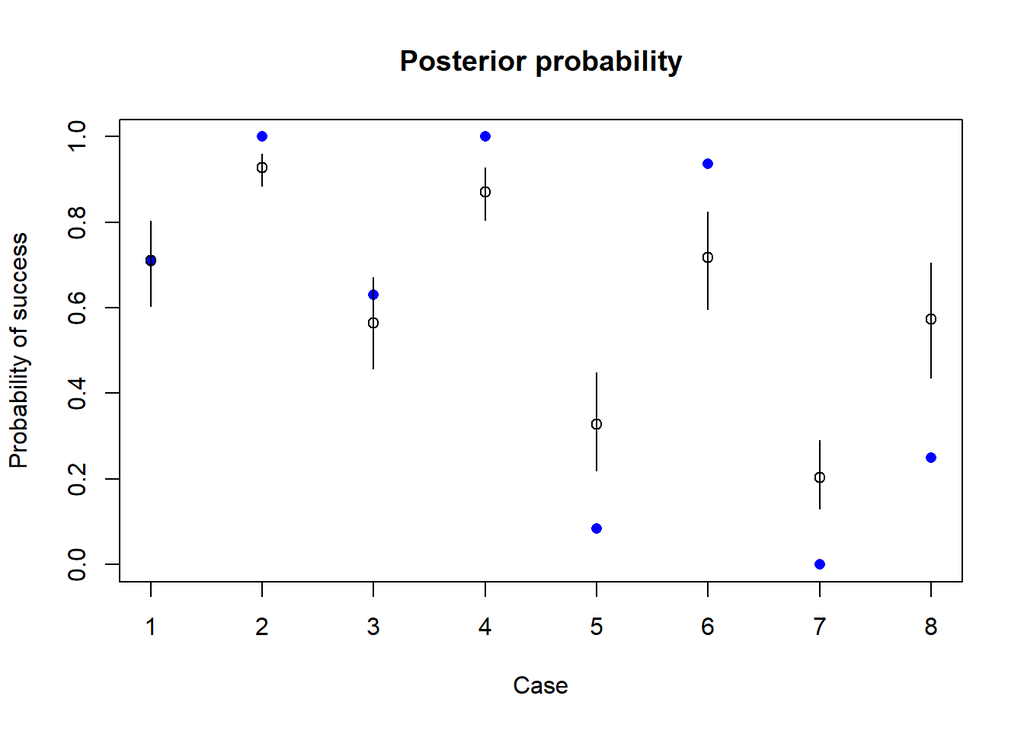

```r
post <- extract.samples(m1.1)
cases = 1:8

# 1. predicted probability
p_link <- link(m1.1)
p_mu <- apply(p_link, 2, mean)
p_pi <- apply(p_link, 2, PI)

plot(eagles$y / eagles$n, xlab="Case", ylab="Probability of success",
     ylim=c(0, 1), pch=16, col="blue", main="Posterior probability")
points(cases, p_mu)
for (i in cases) lines(c(i, i), p_pi[, i])
```

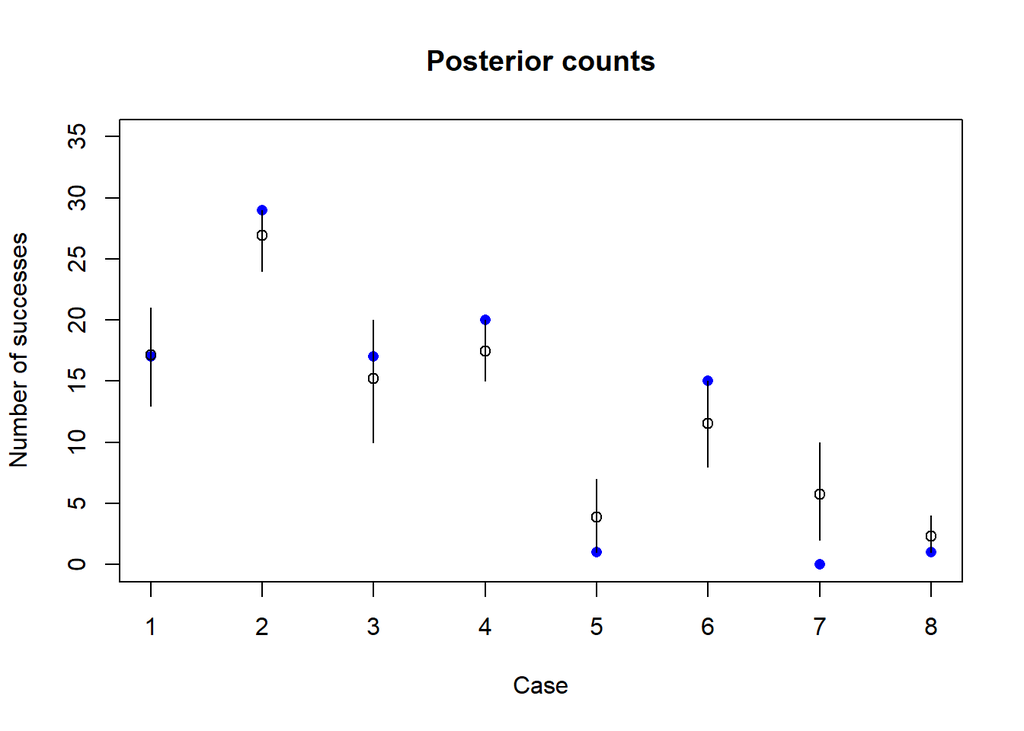

```r
# 2. predicted success count
sim_counts <- sim(m1.1)
s_mu <- apply(sim_counts, 2, mean)
s_pi = apply(sim_counts, 2, PI)

plot(eagles$y, xlab="Case", ylab="Number of successes",
     ylim=c(0, 35), pch=16, col="blue", main="Posterior counts")
points(cases, s_mu)
for (i in cases) lines(c(i, i), s_pi[, i])
```

**What different information does each provide?** The probability plot just shows the uncertainty about the expected proportion of succeses. it only includes parameter uncertainty. The count plot is much wider because it also includes the binomial sampling variation (the noise of the actual outcome happening). It shows the range of actual counts we could observe.

### (c)

Now try to improve model with interaction between pirate size and age.

```r
m1.2 <- ulam(
  alist(
    y ~ dbinom(n, p),
    logit(p) <- a + bP*P + bV*V + bA*A + bPA*P*A,
    a ~ dnorm(0, 1.5),
    c(bP, bV, bA, bPA) ~ dnorm(0, 0.5)
  ), data=dat_list, chains=4, cores=4, log_lik=TRUE
)
```

```r
compare(m1.1, m1.2)
```

```
##          WAIC       SE    dWAIC      dSE    pWAIC    weight
## m1.1 58.37355 11.43372 0.000000       NA 8.089780 0.7313267
## m1.2 60.37627 11.33432 2.002728 1.676592 8.911847 0.2686733
```

## Problem 2

Salamanders data. Density modelled as Poisson.

```r
sal <- read.csv("exercise/salamanders.csv")
```

### (a)

Model relationship between density and percent cover.

```r
dat_sal <- list(
  S = sal$SALAMAN,
  P = sal$PCTCOVER,
  F = sal$FORESTAGE
)

# standardizing predictors is a good practice for weakly informative priors
dat_sal$P_std <- (dat_sal$P - mean(dat_sal$P)) / sd(dat_sal$P)
dat_sal$F_std = (dat_sal$F - mean(dat_sal$F)) / sd(dat_sal$F)

m_sal1 <- ulam(
  alist(
    S ~ dpois(lambda),
    log(lambda) <- a + bP*P_std,
    a ~ dnorm(0, 1),
    bP ~ dnorm(0, 0.5)
  ), data=dat_sal, chains=4, cores=4, log_lik=TRUE
)
```

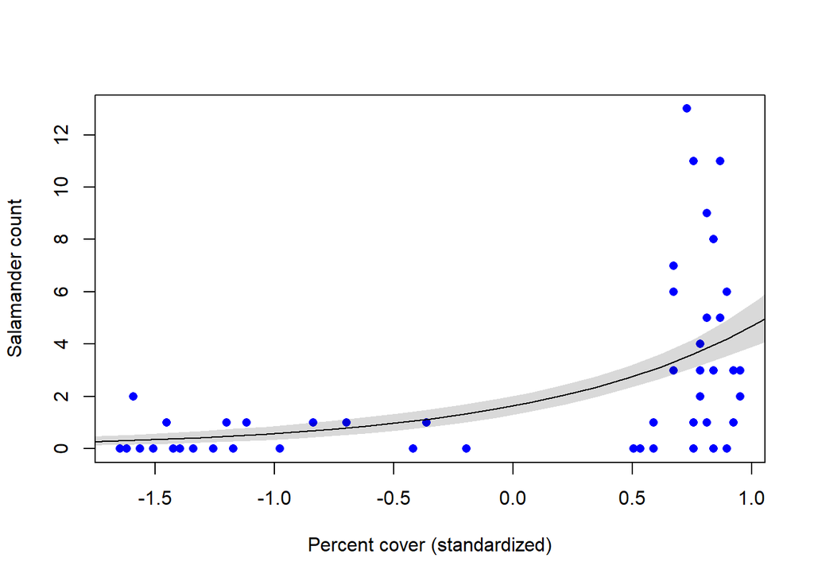

```r
# plotting expected counts
P_seq <- seq(from=-2, to=2, length.out=30)
lambda_link <- link(m_sal1, data=list(P_std=P_seq))
l_mu <- apply(lambda_link, 2, mean)
l_pi <- apply(lambda_link, 2, PI)

plot(dat_sal$P_std, dat_sal$S, col="blue", pch=16,
     xlab="Percent cover (standardized)", ylab="Salamander count")
lines(P_seq, l_mu)
shade(l_pi, P_seq)
```

**In which ways does it do a good job / bad job?** The model does a good job capturing the positive trend (more ground cover means more salamanders). But it does a bad job because the points are very scattered around the expected line. The variance in the data seems larger than what a standard Poisson distribution expects (overdispersion), so the model predictions might be too confident and there are many zeros or very high counts that the model doesn’t fit perfectly.

### (b)

Improve model using FORESTAGE.

```r
m_sal2 <- ulam(
  alist(
    S ~ dpois(lambda),
    log(lambda) <- a + bP*P_std + bF*F_std,
    a ~ dnorm(0, 1),
    c(bP, bF) ~ dnorm(0, 0.5)
  ), data=dat_sal, chains=4, cores=4, log_lik=TRUE
)
```

```r
precis(m_sal2)
```

```
##          mean         sd       5.5%     94.5%     rhat  ess_bulk
## a  0.47957165 0.14585848  0.2393031 0.7087439 1.001885  910.9848
## bF 0.02022852 0.09479325 -0.1355456 0.1716681 1.003855 1132.2384
## bP 1.04149042 0.18330109  0.7663910 1.3560850 1.002826  737.4739
```

```r
compare(m_sal1, m_sal2)
```

```
##            WAIC       SE    dWAIC      dSE    pWAIC     weight
## m_sal1 213.0781 26.45482 0.000000       NA 4.347383 0.91866889
## m_sal2 217.9269 27.35367 4.848794 1.516551 7.561746 0.08133111
```

## Problem 3

NWO grants data. Causal effects of gender on grant awards, mediated by discipline.

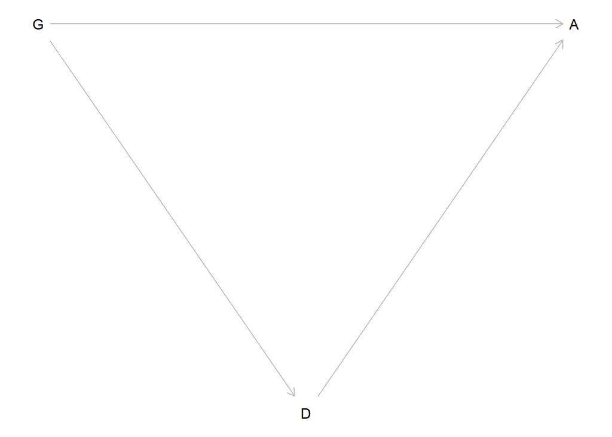

```r
nwo <- read.csv("exercise/NWOGrants.csv")

# DAG
dag_nwo <- dagitty("dag {
  G -> D
  G -> A
  D -> A
}")
coordinates(dag_nwo) <- list(x=c(G=0, D=1, A=2), y=c(G=0, D=1, A=0))
plot(dag_nwo)
```

To find the **total causal effect** of gender on awards, we just model Awards as a function of Gender, without including Discipline (because Discipline is a mediator). To find the **direct causal effect** we include Discipline in the model.

```r
dat_nwo <- list(
  A = nwo$awards,
  N = nwo$applications,
  gid = ifelse(nwo$gender == "m", 1, 2), # 1 = male, 2 = female
  did = as.integer(as.factor(nwo$discipline))
)

# Total effect model
m_nwo_total <- ulam(
  alist(
    A ~ dbinom(N, p),
    logit(p) <- a[gid],
    a[gid] ~ dnorm(0, 1.5)
  ), data=dat_nwo, chains=4, cores=4
)

# Direct effect model
m_nwo_direct <- ulam(
  alist(
    A ~ dbinom(N, p),
    logit(p) <- a[gid] + d[did],
    a[gid] ~ dnorm(0, 1.5),
    d[did] ~ dnorm(0, 1.5)
  ), data=dat_nwo, chains=4, cores=4
)
```

**Interpretation:** In the total effect model, we can see if men get awarded more than women overall. In the direct effect model, we condition on discipline. If the difference between men and women disappears in the direct effect model, it means the total effect was indirect (mediated through discipline). This is the Simpson’s paradox: women might apply to disciplines that have lower funding rates overall, which makes their total award rate lower, even if the direct effect of gender inside each discipline is zero.

**Intervention:** If NWO wants to equalize rates of funding, the most effective intervention would be to increase the funding rates for the disciplines that have a higher proportion of female applicants. Equalizing the baseline award rates across disciplines would fix the indirect disparity.

## Problem 4

Unobserved confound (career stage) influencing choice of discipline and probability of award.

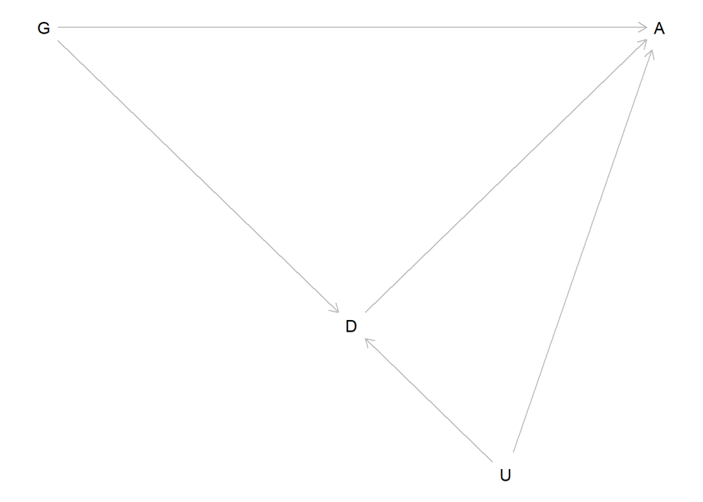

```r
dag_nwo2 <- dagitty("dag {
  G -> D
  G -> A
  D -> A
  U -> D
  U -> A
}")
coordinates(dag_nwo2) <- list(x=c(G=0, D=1, A=2, U=1.5), y=c(G=0, D=1, A=0, U=1.5))
plot(dag_nwo2)
```

**What happens when you condition on discipline?** If we condition on discipline `D`, it opens a backdoor path because `D` is a collider between `G` and `U` (G -> D <- U). This means conditioning on `D` will create a spurious association between Gender and the Unobserved confound `U`, and since `U` affects Awards `A`, it will confound the direct path from Gender to Awards. We will not get an unconfounded estimate of the direct path.

Let’s simulate fake data to show this.

```r
N = 1000
G <- rbinom(N, 1, 0.5) # 0 for women, 1 for men
U <- rnorm(N) # Career stage

# G affects D, U affects D
D <- rbinom(N, 1, plogis(G + U))

# direct effect of G on A is ZERO.
# but U affects A and D affects A
A <- rbinom(N, 1, plogis(D + U))

# test direct effect (condition on D)
m_sim_direct = glm(A ~ G + D, family=binomial)
coef(m_sim_direct)['G']
```

```
##          G
## -0.1697826
```

**Conclusion:** In my simulation, the true direct causal influence of Gender on Awards is ZERO. But when we run the regression conditioning on `D`, the coefficient for `G` becomes non-zero! This happens because of collider bias. So it is entirely possible for the true direct effect to be zero, but conditioning on discipline makes it look completely different.

## Problem 5

Primates data.

```r
primates <- read.csv("exercise/Primates301.csv")
# drop NAs for the variables we need
prim_clean <- primates[complete.cases(primates$social_learning, primates$brain, primates$research_effort), ]

dat_prim <- list(
  S = prim_clean$social_learning,
  log_brain = scale(log(prim_clean$brain)),
  log_effort = scale(log(prim_clean$research_effort))
)
```

### (a)

Poisson for social_learning as a function of log brain size.

```r
m_prim1 <- ulam(
  alist(
    S ~ dpois(lambda),
    log(lambda) <- a + bB*log_brain,
    a ~ dnorm(0, 1),
    bB ~ dnorm(0, 0.5)
  ), data=dat_prim, chains=4, cores=4
)
```

```r
precis(m_prim1)
```

```
##         mean         sd      5.5%      94.5%     rhat ess_bulk
## a  -1.175487 0.11831280 -1.367817 -0.9845146 1.011149 457.7202
## bB  2.761580 0.07520042  2.639944  2.8806276 1.008935 447.1357
```

**Interpretation:** The coefficient `bB` is strongly positive. This means species with larger brains are observed to have much more social learning.

### (b)

Add `research_effort`.

```r
m_prim2 <- ulam(
  alist(
    S ~ dpois(lambda),
    log(lambda) <- a + bB*log_brain + bE*log_effort,
    a ~ dnorm(0, 1),
    c(bB, bE) ~ dnorm(0, 0.5)
  ), data=dat_prim, chains=4, cores=4
)
```

```r
precis(m_prim2)
```

```
##          mean         sd       5.5%      94.5%     rhat ess_bulk
## a  -1.6853678 0.15040814 -1.9341298 -1.4449923 1.007832 674.9965
## bE  2.1162485 0.08870433  1.9741211  2.2591091 1.005418 646.2832
## bB  0.4095711 0.08033804  0.2788885  0.5371646 1.010807 688.1717
```

**Interpretation:** The coefficient for `log_effort` (`bE`) is positive and very large. When we add it, the effect of `log_brain` (`bB`) drops significantly. This differs from the previous model because now we see that a lot of the apparent relationship between brain size and social learning was actually driven by research effort: species with big brains get studied much more, so naturally we observe more social learning from them.

### (c)

DAG for social_learning (S), brain (B), and research_effort (E).

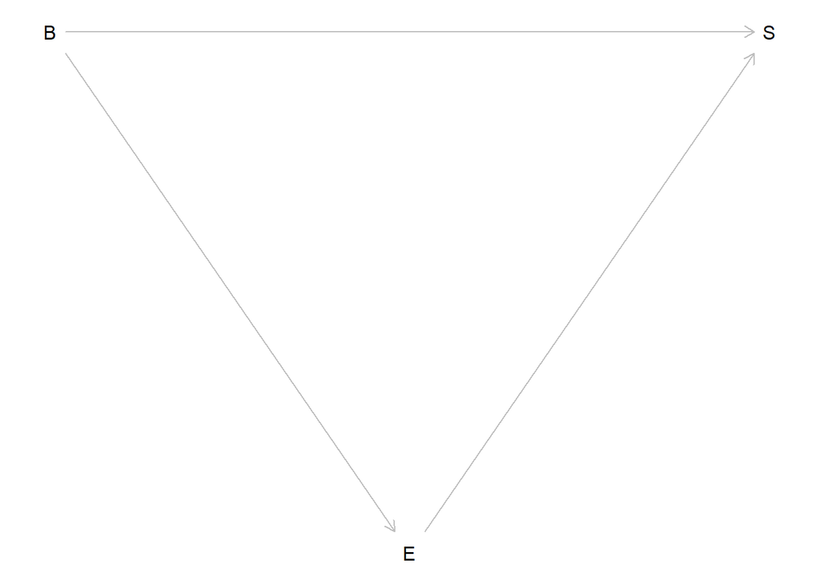

```r
dag_prim <- dagitty("dag {
  B -> S
  B -> E
  E -> S
}")
coordinates(dag_prim) <- list(x=c(B=0, E=1, S=2), y=c(B=0, E=1, S=0))
plot(dag_prim)
```

**Justification:** Brain size influences research effort (humans are more interested in studying big-brained primates). Research effort influences the *observed* amount of social learning (the more you look, the more you find). There might also be a direct effect of Brain on true social learning. Because both B and E have positive coefficients in the models, and B’s coefficient dropped when E was added, E acts as a mediator (or confounder if you consider the causal direction of the bias) between B and observed S.